# DAV5303 HW_2

Rob Rolleston

25 JAN 2022

DUE JAN-31 8:00PM EST  
*NOTE:* Your hw solution may be shared with the class.

## What is being assessed ?

- Your ability to
  - Calculate basic summary statistics
  - Create basic univariate plots with customized styling
  - Use an .RMD to produce an .HTML with stylized summary statistics and charts
- I should be able
  - examine the files
  - (optional: execute your .R file and reproduce your answers)
  - knit your .RMD file and create a .html file
  - read about what you did.

## Submission Details

- A .ZIP file with three files contained within a directory:
  0. (Optional: your .R file used to fill in the chunks of the .RMD)
  1. your .RMD file
  2. your final .html file
- Naming convention for directory & .ZIP
  - RobRolleston_HW12_2022-01-31.zip

## 1) Load data and present summary statistics

Use the file **hw2_DataSet.csv** which has four sets of data A, B, C, D. For each data set calculate mean, median, and 1st and 3rd quartile values.

Present the result of these values in a table. This may prove useful [https://appsilon.com/top-r-packages-for-table-data/] (https://appsilon.com/top-r-packages-for-table-data/)

## 2) Present aligned univariate charts

Now create 3 univariate charts for each set of data:

- Dot Plot
  - think about what mark to use, and the color & opacity of the mark
  - (optionally with some jitter)
- Box Plot
- Histogram

In each plot, add four vertical lines

- *mean* (solid black line)
- *median* (dashed green line)
- *1st an 3rd quartiles* (two dashed blue lines)

These plots should be presented in a grid of 3 rows (type of plot) and 4 columns (each data set). the package `cowplot` has a nice function `plot_grid()` that works well to do this. You can make 12 separate ggplots, or if you want to stretch your skills, you might create some functions.

Below is a very low resolution image of this ‘grid’ with no labeling, showing only the plots for the set D. Your task is to create similar columns for the sets A, B, & C, but with higher resolution, a title, and any other items you think useful.

**NOTE** the alignment of the mean, median, quartiles, and range in all plots in a column. If done properly, these should all align for each set. This worked for me by using the ggplot functions:

- `xlim()`
- `theme(axis.title.y=..., axis.text.y=..., axis.ticks.y=... )`

One purpose of this assignment is to learn how to control aspects of your visuals. I suggest you first work on getting all the basic plots working, then try to combine them in into a grid. If you can’t get the single grid working with good alignment, show what you do have working. Maybe start with getting each set aligned as 3x1, without having them all in one 3x4 grid.

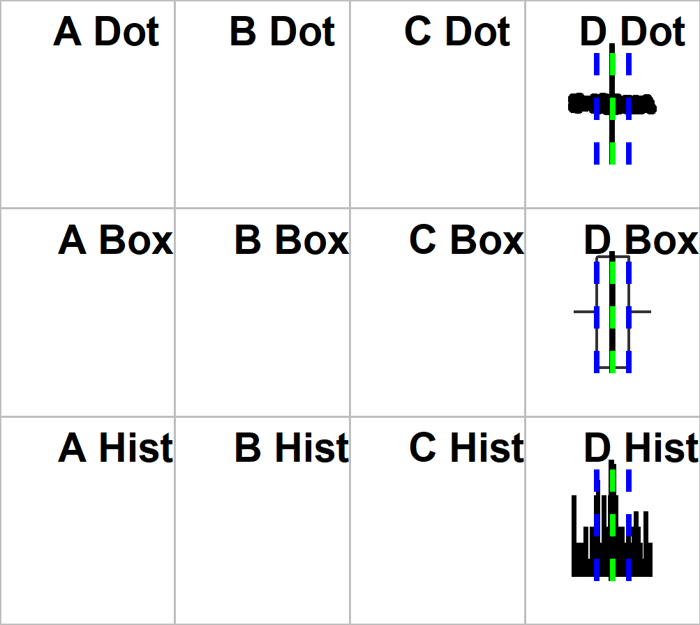

**As always…** If you are stuck, lost, confused, frustrated, etc. … Contact me. I am here to help